# Lab 10 - Space use and resource selection

### Kernel density estimates

Let’s get a bit more nuanced. We’re now going to use the kernelUD() function to calculate kernel density estimates of home ranges for the 6 individuals. Recall that we have to specify both a bandwidth with “h” and a kernel function with “kern”. Here we’re stating that we want to use the Epanechnikov kernel (commonly used). In addition, rather than specifying a specific number for our bandwidth, we are using an algorithm to choose the bandwidth for us based on the variance in the x and y coordinates (href). There are other algorithms one can use (e.g., LSCV - least-square cross validation) but we’re just going simple here.

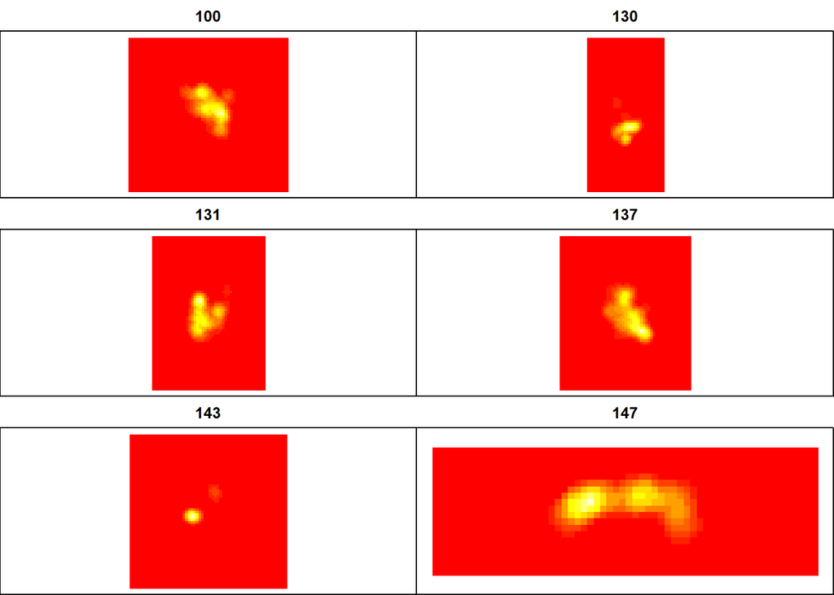

```r
kernelHrefEpa = kernelUD(panthersSp[,'CatID'], h='href', kern='epa')

image(kernelHrefEpa)
```

```r
kernelHrefEpa[[2]]@h
```

```
## $h
## [1] 10421.33
##
## $meth
## [1] "href"
```

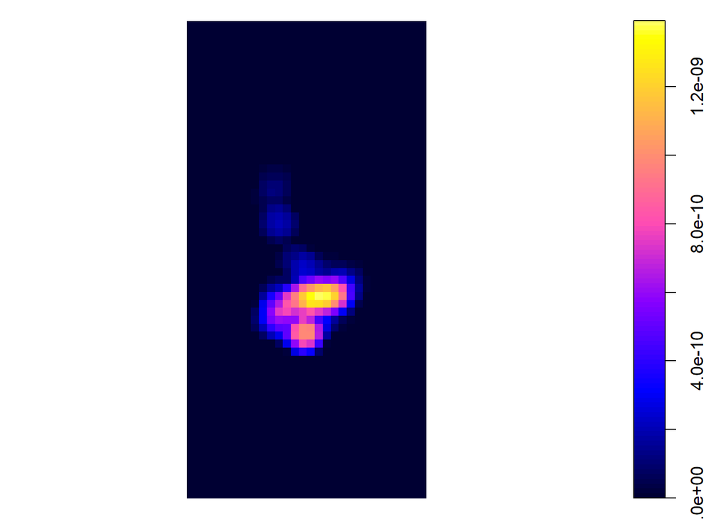

```r
plot(kernelHrefEpa[[2]])
```

```r
kernel.area(kernelHrefEpa)
```

|  | X100 | X130 | X131 | X137 | X143 | X147 |
| --- | --- | --- | --- | --- | --- | --- |
| 20 | 2038.711 | 14748.54 | 3822.950 | 3931.464 | 3221.599 | 31770.76 |
| 25 | 2601.114 | 20647.96 | 4955.676 | 5087.776 | 4142.056 | 41699.12 |
| 30 | 3233.817 | 25072.52 | 6088.402 | 6244.089 | 5062.512 | 51627.48 |
| 35 | 3866.520 | 30971.94 | 7221.128 | 7516.033 | 5982.969 | 63541.52 |
| 40 | 4499.223 | 36871.36 | 8495.445 | 8903.609 | 7363.655 | 75455.55 |
| 45 | 5272.527 | 42770.78 | 9769.761 | 10291.184 | 9204.568 | 87369.58 |
| 50 | 6045.831 | 48670.19 | 11185.669 | 11794.391 | 10585.253 | 101269.29 |
| 55 | 6819.136 | 56044.47 | 12743.167 | 13413.229 | 12886.395 | 117154.67 |
| 60 | 7733.040 | 63418.74 | 14300.665 | 15147.698 | 16107.994 | 131054.38 |
| 65 | 8717.245 | 72267.86 | 15999.754 | 16997.798 | 19329.593 | 148925.43 |

[output cut: 6 more lines]

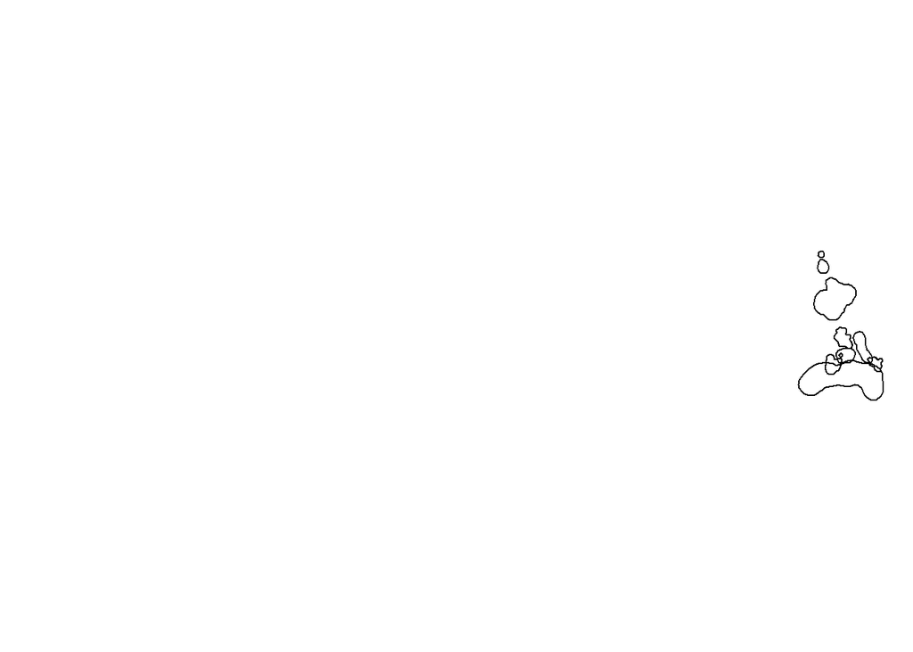

```r
plot(getverticeshr(kernelHrefEpa))

kde95Sf = st_as_sf(getverticeshr(kernelHrefEpa, percent=95))
kde50Sf = st_as_sf(getverticeshr(kernelHrefEpa, percent=50))
```

### Local convex hull (LoCoH)

As always, LoCoH approaches require some decisions. Here, we specifically need to decide how we identify the points that should be aggregated to draw each of the sub-polygons which we will unite to make our home range. We can use a couple of different philosophies:

- k-LoCoH: fixed number of k points considered
- r-LoCoH: fixed sphere of influence - fixed radius within which neighbors are considered
- a-LoCoH: adaptive sphere of influence - a represents the maximum sum of the distances of nearest neighbors that should be considered for each point

You can utilize all of these philosophies within the adehabitatHR package, but here we’re going to focus on k-LoCoH and a-LoCoH for demonstration purposes.

In addition, regardless of which philosophy you choose, you need to find the best parameter value for defining the boundaries for neighbors to include. Usually we do this by starting at some small value and increasing it to evaluate how that changes our estimates of the home range area. As k, r, or a increases, there will be fewer “holes’ leading to a home range polygon with a coarser grain. Ideally, the home range size will level off once all spurious holes are covered then increase again when one or more real holes become covered (Getz et al. 2007).

To identify the appropriate value, it is recommended you start k at N^0.5 (where N is the number of points for the individual) and increase slowly. For a, it is suggested you start at the maximum distance between pairs of points.

```r
panther147 = panthersSp[panthersSp$CatID==147,]

kInit = round(nrow(coordinates(panther147))^0.5, 0)
aInit = round(max(dist(coordinates(panther147))),0)

kSearch = seq(kInit, 10*kInit, by=5) #number of points
aSearch = seq(aInit, 2*aInit, by=3000) #distance in m

locohArange = LoCoH.a.area(SpatialPoints(coordinates(panther147)), arange=aSearch)
```

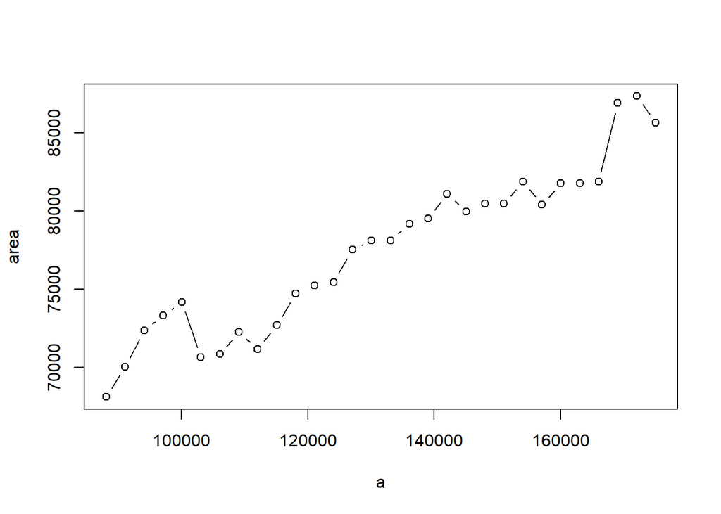

```r
locohKrange = LoCoH.k.area(SpatialPoints(coordinates(panther147)), krange=kSearch)
```

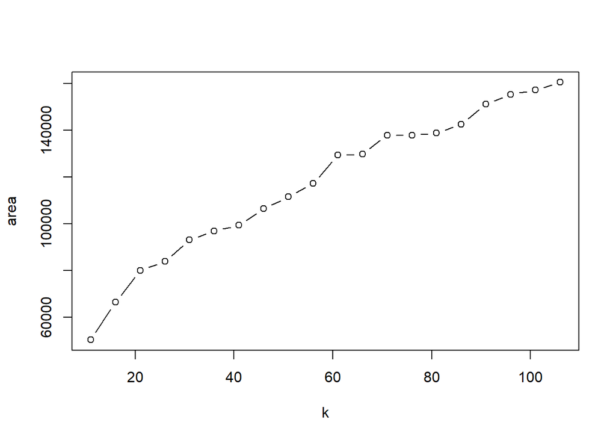

From this, we can see that the rate of increase in home range area slows somewhere around the 5th value of a. It’s more subtle with k, but there seems to be a slowing of the increase somewhere around the 11th value considered. So we’ll use these values to calculate our LoCoH home ranges below.

```r
aSearch[5]
```

```
## [1] 100062
```

```r
kSearch[11]
```

```
## [1] 61
```

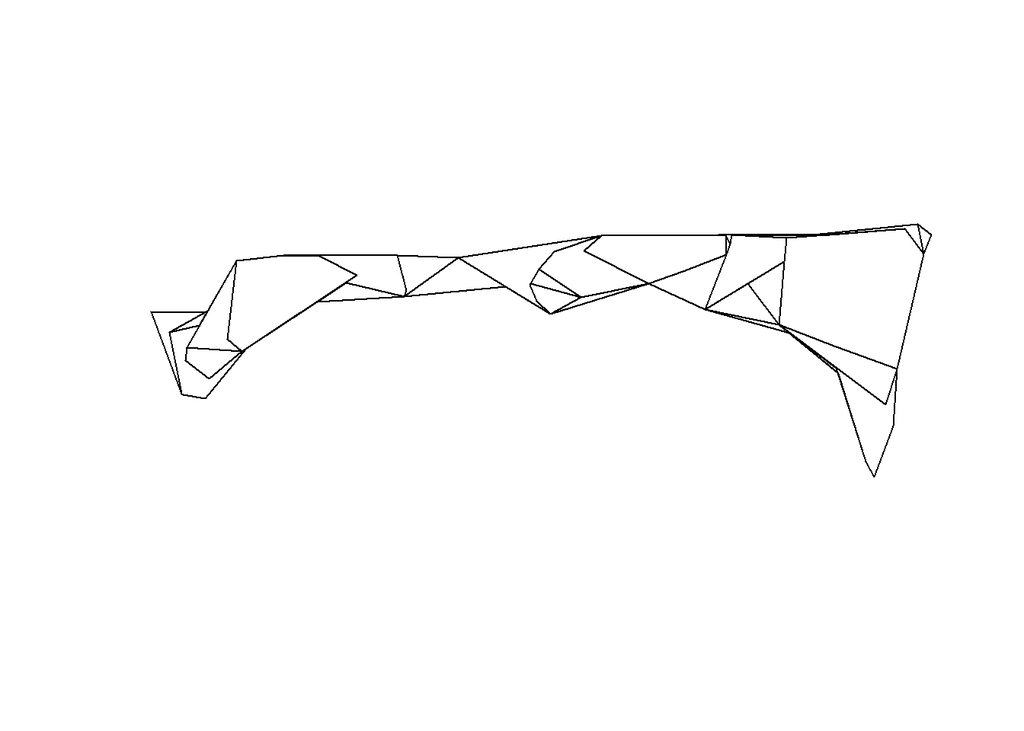

```r
locohA = LoCoH.a(SpatialPoints(coordinates(panther147)), a=aSearch[5])
plot(locohA)
```

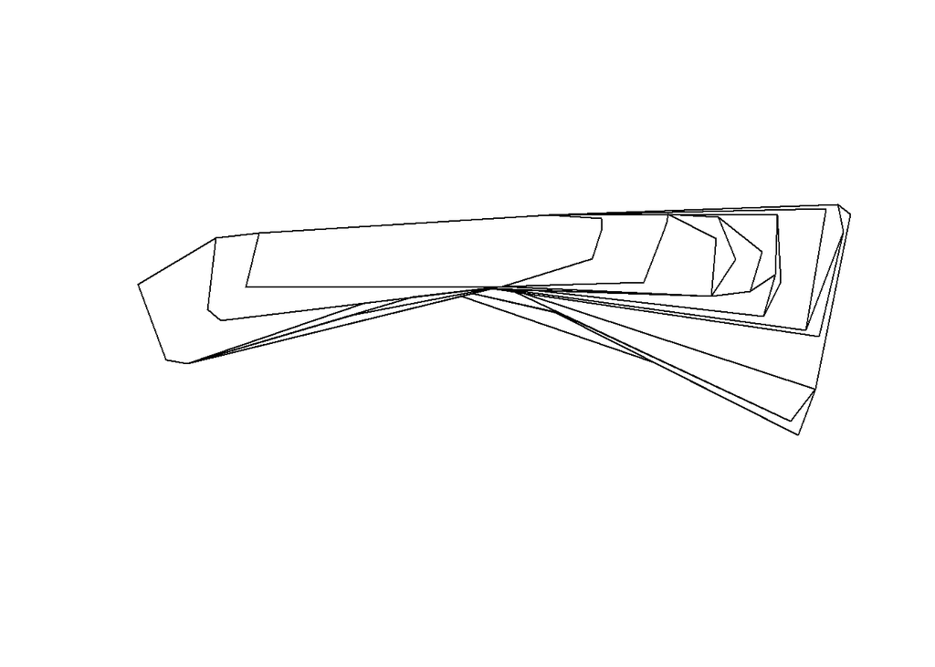

```r
locohK = LoCoH.k(SpatialPoints(coordinates(panther147)), k = kSearch[11])
plot(locohK)
```

```r
locohASf = st_as_sf(locohA)
locohKSf = st_as_sf(locohK)
```

Note that every single point gets a polygon. The function then starts by reporting the smallest polygon, then the two smallest merged together, then the three smallest, etc. until we have 123 total polygons. In this way, you can pull out something close to a 50% or a 95% home range by selecting the polygon with the area value closest to the percent you’re interested in.

```r
# view(locohASf)

locohA56Sf = locohASf[26,]
locohA92Sf = locohASf[97,]

#And of course, you can do the same with your output from locohK
```

### Brownian bridge movement models

Fitting Brownian bridge home range models requires a bit of a different format for the data that captures the trajectory and temporal relationship between points. We can use the adehabitatLT package to create a trajectory object.

```r
substrRight = function(x, n){
  substr(x, nchar(x) - n+1, nchar(x))
}

panthersSp = panthers %>%
  mutate(Juldate = as.character(Juldate)) %>%
  mutate(date = as.numeric(substrRight(Juldate, 3))) %>%
  mutate(Date = as.Date(date, origin=as.Date("2006-01-01"))) %>%
  mutate(Date = as.POSIXct(Date, "%Y-%m-%d")) %>%
  as('Spatial')

pantherLtraj = as.ltraj(xy=coordinates(panthersSp), date=panthersSp$Date, id=panthersSp$CatID, typeII=T)
```

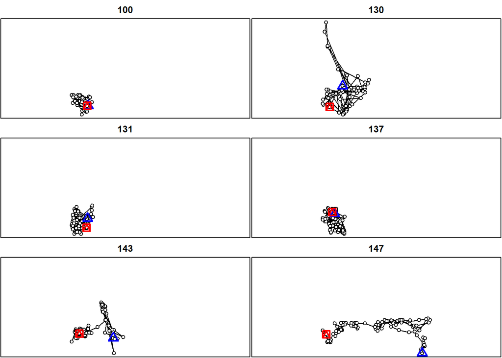

```r
plot(pantherLtraj)
```

We have to estimate two parameters to fit a Brownian bridge model. The first is sig1 which relates to the speed of the individual. As sig1 increases, the assumed path tortuosity increases. We also need to estimate sig2 which is similar to h in KDE and reflects the error in location data. Increases in sig2 leads to increases in smoothing.

We estimate sig1 with maximum likelihood using the liker() function.

```r
sigma1 = liker(pantherLtraj, sig2=450, rangesig1=c(2, 100))
```

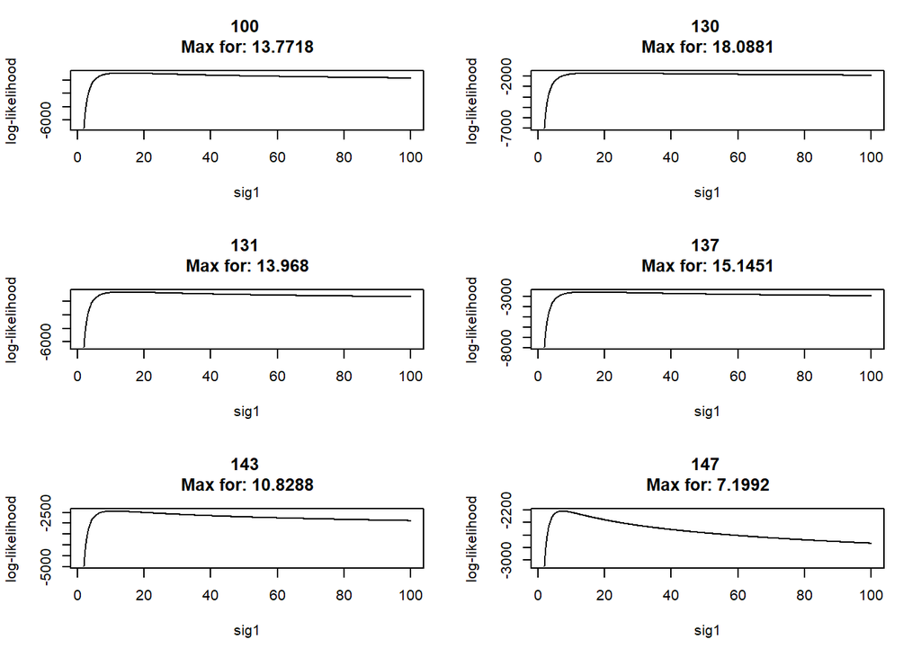

```r
sigma1
```

```
##
## Maximization of the log-likelihood for parameter
## sig1 of brownian bridge
##
## 100 : Sig1 = 13.7718 Sig2 = 450
## 130 : Sig1 = 18.0881 Sig2 = 450
## 131 : Sig1 = 13.968 Sig2 = 450
## 137 : Sig1 = 15.1451 Sig2 = 450
## 143 : Sig1 = 10.8288 Sig2 = 450
## 147 : Sig1 = 7.1992 Sig2 = 450
```

Because there is substantial variation in sig1, we’re going to fit the Brownian bridge model separately for each panther. We will do this for panther 147 for demonstration purposes.

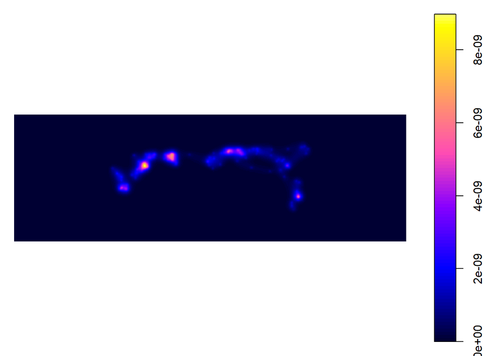

```r
bb147 = kernelbb(pantherLtraj[6], sig=7.2, sig2=450, grid=500)
plot(bb147)
```

```r
bb95Sf = st_as_sf(getverticeshr(bb147, percent=95))
bb50Sf = st_as_sf(getverticeshr(bb147, percent=50))
```

# Quantifying habitat within a home range

```r
habMcp50 = extract(land, mcp50Sf) %>%
  rename(landcover = Description2) %>%
  group_by(ID, landcover) %>%
  summarise(habCells = n()) %>%
  ungroup() %>%
  group_by(ID) %>%
  mutate(totCells = sum(habCells)) %>%
  ungroup() %>%
  mutate(propCells = habCells/totCells) %>%
  pivot_wider(id_cols = ID, names_from = landcover, values_from = propCells, values_fill=0) %>%
  mutate(ID = mcp50Sf$id)
```

[output not shown]

```r
habMcp50
```

| ID | OpenWater | PastureGrassland | Barren | Freshwatermarsh | Scrub/Shrub | CypressSwamp | Pineland | HardwoodSwamp | UplandForest | Cropland | Urban | Dryprairie |
| --- | --- | --- | --- | --- | --- | --- | --- | --- | --- | --- | --- | --- |
| 100 | 0.0102564103 | 0.1794871795 | 0.010256410 | 0.12820513 | 0.03589744 | 0.16923077 | 0.13846154 | 0.323076923 | 0.005128205 | 0.000000000 | 0.000000000 | 0.00000000 |
| 130 | 0.0005599104 | 0.2374020157 | 0.030235162 | 0.09518477 | 0.07446809 | 0.03807391 | 0.14781635 | 0.058790594 | 0.029675252 | 0.022956327 | 0.027995521 | 0.23684211 |
| 131 | 0.0022779043 | 0.0159453303 | 0.134396355 | 0.03416856 | 0.02505695 | 0.24145786 | 0.08200456 | 0.143507973 | 0.022779043 | 0.277904328 | 0.006833713 | 0.01366743 |
| 137 | 0.0837209302 | 0.1116279070 | 0.000000000 | 0.40697674 | 0.05116279 | 0.05116279 | 0.04883721 | 0.009302326 | 0.125581395 | 0.004651163 | 0.002325581 | 0.10465116 |
| 143 | 0.0032573290 | 0.2899022801 | 0.061889251 | 0.09771987 | 0.01954397 | 0.07817590 | 0.08469055 | 0.140065147 | 0.029315961 | 0.087947883 | 0.006514658 | 0.10097720 |
| 147 | 0.0040376851 | 0.0006729475 | 0.002018843 | 0.24495289 | 0.03297443 | 0.34656797 | 0.10969044 | 0.217362046 | 0.013458950 | 0.000000000 | 0.017496635 | 0.01076716 |